# Three-Way Equity Classifier Comparison

GICS Sectors vs. SIC/FF12 Industries vs. K-Means Co-Movement Clusters

Group 8 | University of South Florida

2026-04-27

# Executive summary

This project asks whether data-driven groupings of S&P 500 stocks classify firms differently from traditional industry standards, and whether those differences add value for forward-alpha prediction and anomaly detection. We compare three classification systems head-to-head:

1. **GICS sectors** — the eleven Global Industry Classification Standard sectors that the index providers use.
2. **SIC-based FF12 industries** — Ken French’s twelve-industry partition, which is built directly from SIC codes and is the academic-finance counterpart to GICS.
3. **K-Means clusters on return co-movement** — an unsupervised partition that groups stocks whose monthly excess returns move together over a rolling sixty-month window, refit annually with label matching.

All three schemes are fed through the same downstream pipeline on the same data, and we compare them on four dimensions: composition overlap, within-group homogeneity, predictive accuracy on one-month-forward alpha, and anomaly-detection behaviour.

Two design choices, made in response to feedback on an earlier draft of this project, deserve to be flagged at the top:

- **The target is alpha, not raw return.** Predicting realised return from factor exposures would mostly recover the standard risk premia (high-beta stocks earn higher returns on average) — a tautology, not a finding. The economically interesting quantity is the residual after factor exposure is priced out, i.e. realised alpha. We predict $\alpha_{i,t+1}$ throughout.
- **FF factors enter as features only with a publication lag.** Ken French’s data library publishes FF5 with a multi-month delay, so a forecast that consumes contemporaneous FF values would be unusable in real time. Every feature derived from FF returns is lagged by 2 months. (Realised alpha at month $t$ is computed from $F_t$, but it is a *label* — never a feature input — so this is internally consistent.)

The dataset and pipeline are built with a reproducible configuration object (`CFG`). The submitted report is rendered with `CFG$dev_mode = FALSE`, so the analysis uses the broader S&P 500 panel rather than the earlier small dev-mode sample. The 50-stock option remains in the code only as a debugging switch for faster iteration.

# 1. Research question

Do data-driven groupings of S&P 500 stocks produce a meaningfully different classification than GICS and SIC/FF12, and do those differences improve forward-alpha prediction or anomaly detection?

This restates the question we posed in the original project blueprint in two ways. First, we no longer compare an industry classification (GICS) to a *risk* taxonomy (FF5 loadings), because those are incommensurable. The right comparison set for an industry classification is other industry classifications — GICS, SIC/FF12, and an unsupervised industry-style clustering. Second, we judge “better classification” not just on predictive R² but also on within-group homogeneity (do members really behave alike?) and on anomaly-flagging quality (do flagged outliers subsequently earn different forward alpha?).

# 2. Methods

## 2.1 The three classification schemes

**GICS sectors.** Eleven sectors assigned per stock-month via the CRSP/Compustat Merged (CCM) linkage. Membership is point-in-time: a stock that switches sectors mid-sample carries the new sector going forward.

**SIC/FF12.** Each stock-month’s SIC code (from CRSP `stocknames`, respecting historical name ranges) is mapped to one of twelve Ken French industries. SIC codes that fall outside any range get assigned to “Other.”

**K-Means clusters on return co-movement.** At the end of each calendar year, we take the prior sixty months of monthly excess returns. For each stock with at least thirty-six valid months we form a feature vector equal to that stock’s column of the cross-sectional correlation matrix — i.e. each stock is described by its correlation with every other stock in the panel. We reduce to ten principal components and fit K-Means for $k \in \{2, \ldots, 10\}$, picking $k$ that maximises the mean silhouette. The fitted assignment is used for all twelve months of the following calendar year. Cluster identities are kept stable across refits by Hungarian-algorithm matching against the previous fit’s labels.

## 2.2 Target: realised alpha

For each stock-month we compute realised alpha as the residual from the five-factor model:
$$\alpha_{i,t} \;=\; r^e_{i,t} \;-\; \sum_{k \in \{\text{Mkt},\text{SMB},\text{HML},\text{RMW},\text{CMA}\}} \hat\beta_{i,k}\, F_{k,t},$$
where $r^e_{i,t}$ is excess return and $\hat\beta_{i,k}$ is estimated by OLS on the 36-month window ending at month $t-2$. The forward target used throughout is $\alpha_{i,t+1}$ — realised alpha one month ahead — attached to the row at month $t$.

## 2.3 Features

The feature vector at month $t$ contains:

- Cross-sectionally z-scored FF5 betas (`z_beta_*`), ranking each stock against the cross-section at the same date.
- 12-1 momentum (cumulative return from $t-12$ to $t-2$), 12-month vol of excess returns, and log market cap lagged one month.
- Lagged macro: 10-year Treasury yield, Fed funds rate, VIX — each lagged one month.
- Lagged FF5 returns (`mkt_rf_lag`, `smb_lag`, `hml_lag`, `rmw_lag`, `cma_lag`) — each lagged 2 months to honour the publication delay.

## 2.4 Evaluation

Train: January 2018 – December 2022 (after the 36-month rolling-beta warm-up consumes 2014–2017). Holdout: January 2023 – December 2024. All metrics report on the holdout.

# 3. Data assembly

## 3.1 Pull CRSP / CCM-linked classification data

Historical S&P 500 membership, monthly returns adjusted for delisting, historical SIC codes, and GICS via the CRSP/Compustat Merged (CCM) linkage. The return panel is CRSP-based, while GICS classifications enter through the CCM/Compustat link, so this section uses the broader label “CRSP / CCM-linked” rather than treating the pull as purely one database.

S&P 500 membership spans

| spans | permnos | earliest_start | latest_end |
| --- | --- | --- | --- |
| 476 | 476 | 1964-03-31 | 2024-12-31 |

Monthly return panel

| rows | permnos | months | delisting_obs | pct_ret_present |
| --- | --- | --- | --- | --- |
| 62907 | 498 | 132 | 0 | 0.999 |

## 3.2 Pull Ken French

```
[19:13:46] Pulling Ken French data
[19:13:46] cache hit:  data/raw/ff5.parquet
[19:13:46] cache hit:  data/raw/ff12_def.parquet
```

FF5 factors — head and tail

| date_eom | mkt_rf | smb | hml | rmw | cma | rf |
| --- | --- | --- | --- | --- | --- | --- |
| 1963-07-31 | -0.0039 | -0.0048 | -0.0081 | 0.0064 | -0.0115 | 0.0027 |
| 1963-08-31 | 0.0508 | -0.0080 | 0.0170 | 0.0040 | -0.0038 | 0.0025 |
| 1963-09-30 | -0.0157 | -0.0043 | 0.0000 | -0.0078 | 0.0015 | 0.0027 |
| 2025-12-31 | -0.0036 | -0.0022 | 0.0242 | 0.0040 | 0.0037 | 0.0034 |
| 2026-01-31 | 0.0103 | 0.0326 | 0.0372 | 0.0182 | 0.0183 | 0.0030 |
| 2026-02-28 | -0.0117 | 0.0063 | 0.0283 | 0.0162 | 0.0507 | 0.0028 |

FF12 industry definitions

| industry_num | industry_code | industry_name | n_sic_ranges |
| --- | --- | --- | --- |
| 1 | NoDur | Consumer Nondurables – Food, Tobacco, Textiles, Apparel, Leather, Toys | 6 |
| 2 | Durbl | Consumer Durables – Cars, TVs, Furniture, Household Appliances | 10 |
| 3 | Manuf | Manufacturing – Machinery, Trucks, Planes, Off Furn, Paper, Com Printing | 14 |
| 4 | Enrgy | Oil, Gas, and Coal Extraction and Products | 2 |
| 5 | Chems | Chemicals and Allied Products | 2 |
| 6 | BusEq | Business Equipment – Computers, Software, and Electronic Equipment | 5 |
| 7 | Telcm | Telephone and Television Transmission | 1 |
| 8 | Utils | Utilities | 1 |
| 9 | Shops | Wholesale, Retail, and Some Services (Laundries, Repair Shops) | 3 |
| 10 | Hlth | Healthcare, Medical Equipment, and Drugs | 4 |
| 11 | Money | Finance | 1 |

## 3.3 Pull FRED

```
[19:13:46] Pulling FRED data
[19:13:46] cache hit:  data/raw/fred_dgs10.parquet
[19:13:46] cache hit:  data/raw/fred_dff.parquet
[19:13:46] cache hit:  data/raw/fred_vixcls.parquet
```

FRED macro coverage

| months | earliest | latest | pct_ten_y | pct_ffr | pct_vix |
| --- | --- | --- | --- | --- | --- |
| 132 | 2014-01-31 | 2024-12-31 | 1 | 1 | 1 |

## 3.4 Build the panel

```
[19:13:46] Building master panel
[19:13:46]   panel keys: 52221 rows
[19:13:50]   wrote: data/processed/panel.parquet
```

Master panel coverage

| rows | permnos | months | pct_ret_excess | pct_gics | pct_ff12 | pct_macro |
| --- | --- | --- | --- | --- | --- | --- |
| 52221 | 476 | 132 | 1 | 1 | 1 | 1 |

GICS sector distribution at 2024-12-31

| gics_sector_name | n |
| --- | --- |
| Industrials | 76 |
| Financials | 71 |
| Information Technology | 66 |
| Health Care | 58 |
| Consumer Discretionary | 45 |
| Consumer Staples | 35 |
| Real Estate | 31 |
| Utilities | 31 |
| Materials | 25 |
| Energy | 21 |
| Communication Services | 17 |

FF12 industry distribution at 2024-12-31

| ff12_num | ff12_code | n |
| --- | --- | --- |
| 11 | Money | 95 |
| 6 | BusEq | 84 |
| 12 | Other | 61 |
| 3 | Manuf | 49 |
| 10 | Hlth | 40 |
| 9 | Shops | 35 |
| 8 | Utils | 34 |
| 1 | NoDur | 28 |
| 5 | Chems | 18 |
| 4 | Enrgy | 16 |
| 7 | Telcm | 9 |
| 2 | Durbl | 7 |

# 4. Feature engineering

```
[19:13:50] Building features (FF lag = 2 months, loading lag = 2 months)
[19:13:50] Computing rolling FF5 betas
[19:13:55]   wrote: data/processed/features.parquet
```

## 4.1 Coverage

Feature panel coverage

| rows | pct_loadings | pct_realized_alpha | pct_fwd_target | modelable |
| --- | --- | --- | --- | --- |
| 52221 | 0.68 | 0.68 | 0.68 | 0.672 |

## 4.2 Anti-leakage tests

The critical invariant: `alpha_fwd_1m` at $(i, t)$ must equal `alpha_realized` at $(i, t+1)$ for every paired row. We also verify that the lagged FF5 columns match a manual lag operation.

```
[19:13:55] Running leakage tests
# A tibble: 3 × 2
  test                                                passed
  <chr>                                               <lgl>
1 alpha_fwd_1m == lead(alpha_realized)                TRUE
2 rolling betas use only data through t - loading_lag TRUE
3 *_lag features match manual lag                     TRUE
```

## 4.3 Distributions

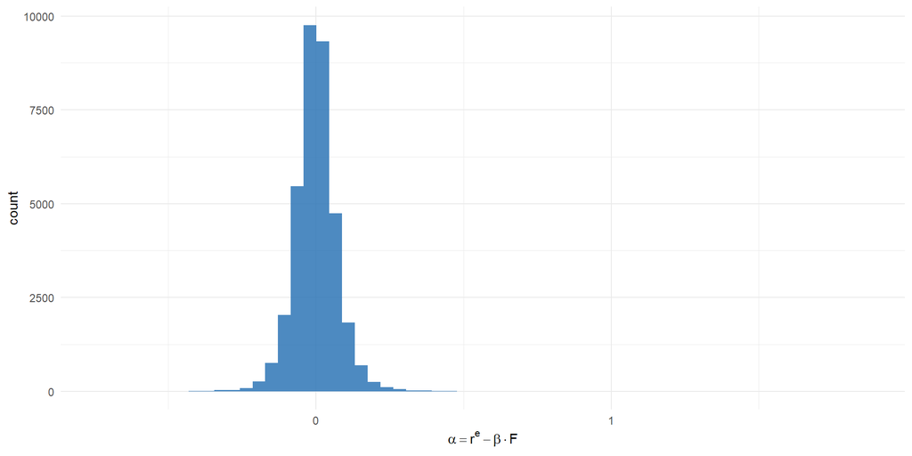

Realised monthly alpha — symmetric around zero, fat-tailed.

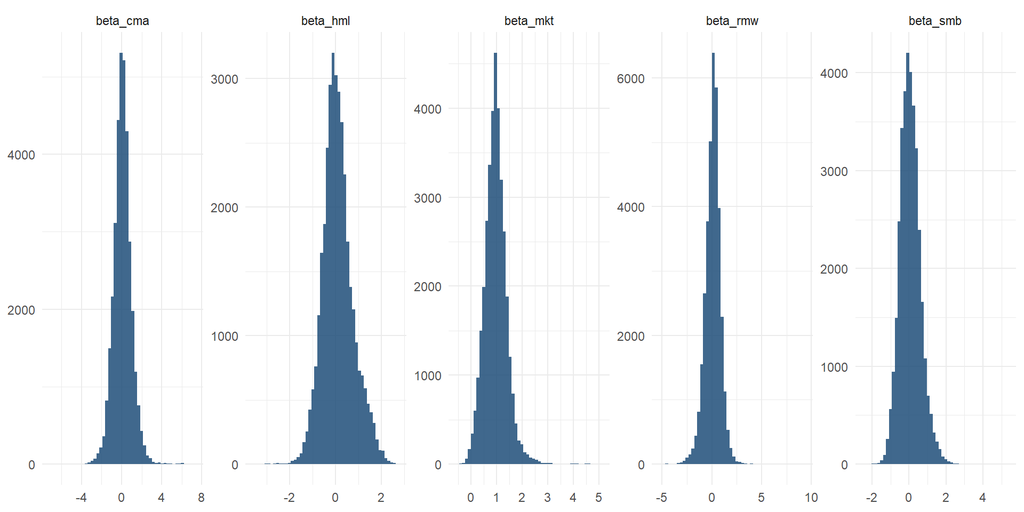

FF5 betas across the panel — mostly market-driven.

# 5. Clustering on return co-movement

K-Means is fit at the end of each year on the prior sixty months; the assignment is applied to all twelve months of the following calendar year.

```
[19:13:56] Building annual K-Means clusters on return co-movement
[19:13:56]   refit 2017-12-31: k=2, sil=0.333, n=325
[19:13:56]   refit 2018-12-31: k=2, sil=0.415, n=339
[19:13:56]   refit 2019-12-31: k=2, sil=0.433, n=358
[19:13:56]   refit 2020-12-31: k=2, sil=0.404, n=379
[19:13:57]   refit 2021-12-31: k=2, sil=0.358, n=391
[19:13:57]   refit 2022-12-31: k=2, sil=0.338, n=409
[19:13:57]   refit 2023-12-31: k=2, sil=0.339, n=421
```

Cluster diagnostics by refit date

| refit_date | k | silhouette | n_stocks |
| --- | --- | --- | --- |
| 2017-12-31 | 2 | 0.333 | 325 |
| 2018-12-31 | 2 | 0.415 | 339 |
| 2019-12-31 | 2 | 0.433 | 358 |
| 2020-12-31 | 2 | 0.404 | 379 |
| 2021-12-31 | 2 | 0.358 | 391 |
| 2022-12-31 | 2 | 0.338 | 409 |
| 2023-12-31 | 2 | 0.339 | 421 |

The number of stocks in the clustering diagnostics can be lower than the constituent count reported earlier because the embedding requires enough valid monthly return history inside the rolling window. Stocks with too few valid observations are excluded from a given annual refit rather than being forced into a noisy correlation estimate.

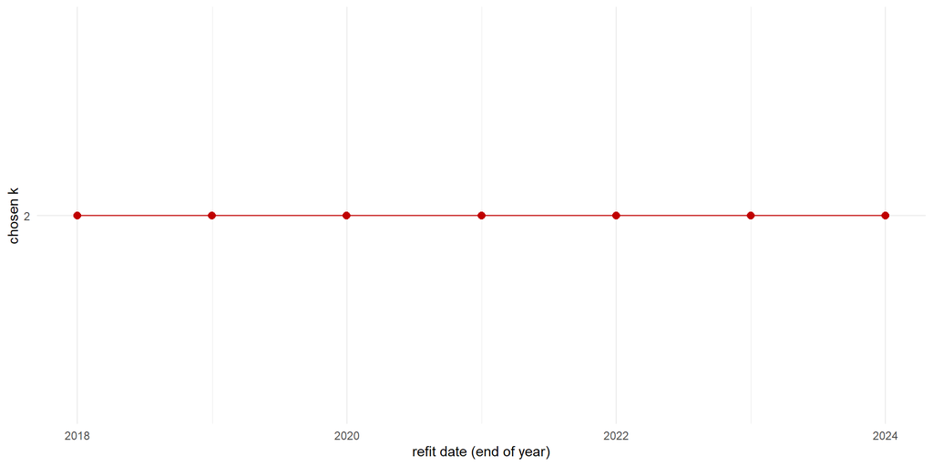

Chosen k by refit year. The repeated selection of k = 2 is a finding: monthly stock-return co-movement is dominated by a broad two-regime structure rather than many clean industry-like clusters.

The consistent selection of `k = 2` should be read as a substantive result, not as a failed attempt to recreate industry sectors. At the monthly horizon, the S&P 500 return-correlation matrix appears to be dominated by one broad principal axis, broadly interpretable as market-beta or risk-regime exposure. That means the K-Means scheme is best interpreted as a coarse cross-sector risk-regime split, not as a fine-grained substitute for GICS or SIC/FF12.

# 6. Three-way comparison

## 6.1 Composition

How much do the three groupings overlap?

Adjusted Rand index between scheme pairs

| comparison | adj_rand | n_stocks |
| --- | --- | --- |
| GICS vs FF12 | 0.464 | 421 |
| GICS vs Cluster | 0.048 | 421 |
| FF12 vs Cluster | 0.033 | 421 |

The adjusted Rand index measures partition similarity, with 1 = identical and 0 = random. Values close to zero between GICS or FF12 and the K-Means clusters mean the unsupervised partition is genuinely different from the industry partitions, which is what we’d want — otherwise it adds nothing.

GICS sector × K-Means cluster (most recent month)

|  | 1 | 2 |
| --- | --- | --- |
| Communication Services | 7 | 10 |
| Consumer Discretionary | 8 | 34 |
| Consumer Staples | 23 | 9 |
| Energy | 1 | 17 |
| Financials | 9 | 55 |
| Health Care | 35 | 17 |
| Industrials | 9 | 58 |
| Information Technology | 14 | 37 |
| Materials | 3 | 20 |
| Real Estate | 7 | 20 |
| Utilities | 22 | 6 |

FF12 industry × K-Means cluster (most recent month)

|  | 1 | 2 |
| --- | --- | --- |
| BusEq | 24 | 42 |
| Chems | 5 | 12 |
| Durbl | 1 | 5 |
| Enrgy | 1 | 14 |
| Hlth | 23 | 12 |
| Manuf | 5 | 37 |
| Money | 19 | 66 |
| NoDur | 13 | 11 |
| Other | 7 | 50 |
| Shops | 15 | 20 |
| Telcm | 3 | 6 |
| Utils | 22 | 8 |

## 6.2 Within-group homogeneity

A “good” classification produces internally similar members. We measure this two ways: the cross-sectional standard deviation of realised alpha within each group at each date (lower = more homogeneous in unexplained returns), and the mean pairwise correlation of excess returns among group members (higher = more co-moving).

Within-group homogeneity by scheme

| scheme | mean_alpha_sd | median_alpha_sd | mean_within_corr | median_within_corr |
| --- | --- | --- | --- | --- |
| GICS | 0.0626 | 0.0587 | 0.4710 | 0.4505 |
| FF12 | 0.0638 | 0.0599 | 0.4525 | 0.4432 |
| Cluster | 0.0679 | 0.0642 | 0.3366 | 0.3366 |

Because the K-Means clusters are estimated from return co-movement, they are expected to capture broad cross-sector return regimes. However, they do not need to dominate GICS or FF12 on every homogeneity statistic. If GICS or FF12 has a higher `mean_within_corr`, that suggests traditional industry labels still form tighter, more interpretable groups, while K-Means may be capturing a broader risk/return segmentation instead of narrow industry similarity.

## 6.3 Predictive accuracy

Per-group Elastic Net regressions predict $\alpha_{i,t+1}$ from the feature set. We report out-of-sample R², MAE, and directional accuracy on the 2023–2024 holdout, weighted by group size.

```
[19:13:57] Prediction: train n=7281, test n=3336
```

Aggregate prediction metrics by scheme

| scheme | n_test_total | r2_oos_weighted | mae_weighted | dir_acc_weighted | n_groups |
| --- | --- | --- | --- | --- | --- |
| Cluster | 3302 | -0.0844 | 0.0562 | 0.4761 | 2 |
| Pooled | 3336 | -0.0936 | 0.0567 | 0.4661 | 1 |
| GICS | 3336 | -0.2813 | 0.0619 | 0.4865 | 11 |
| FF12 | 3336 | -0.4075 | 0.0649 | 0.4766 | 12 |

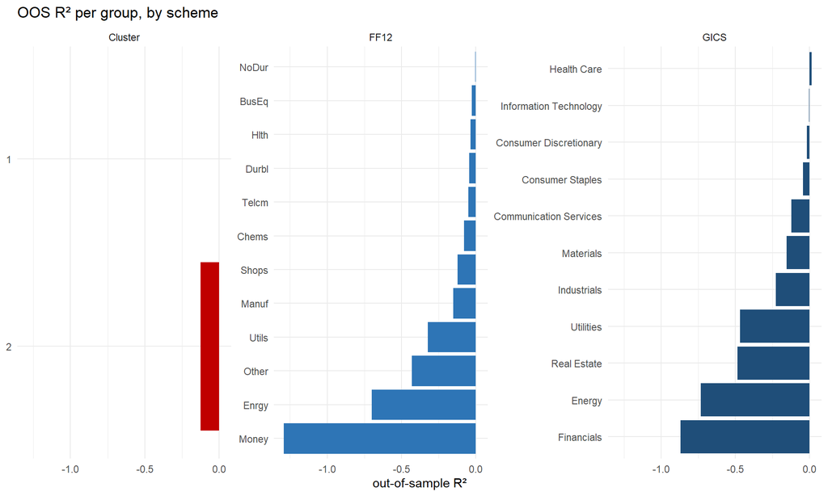

The pooled baseline (no grouping) gives a single all-stocks Elastic Net. In this full-panel render, the Cluster scheme is the only grouped model that beats the pooled baseline on both out-of-sample R² and directional accuracy, even though the margin is modest. This is important because the K-Means model uses only a coarse two-cluster split, so it adds forecasting structure without fragmenting the training data into as many small industry-specific regressions as GICS or FF12. The negative R² values still show that alpha forecasting is difficult overall, but the relative ranking suggests that a broad co-movement risk-regime split can be more useful for prediction than finer industry labels when the per-stock signal is weak.

## 6.4 Anomaly detection

Isolation Forest is trained per group on the train window and scored on the holdout; the most anomalous five percent are flagged. We then look at average forward alpha at one, three, and six months for flagged versus non-flagged stocks.

```
[19:13:59]   iForest within GICS
[19:13:59]   iForest within FF12
[19:13:59]   iForest within Cluster
```

Mean forward alpha for flagged vs. non-flagged stocks, by scheme and horizon

| scheme | flagged | horizon | n | mean_fwd_alpha | median_fwd_alpha |
| --- | --- | --- | --- | --- | --- |
| Cluster | FALSE | 1 | 3135 | -0.0050 | -0.0053 |
| Cluster | TRUE | 1 | 167 | -0.0149 | -0.0082 |
| Cluster | FALSE | 3 | 2737 | -0.0031 | -0.0028 |
| Cluster | TRUE | 3 | 161 | 0.0054 | 0.0104 |
| Cluster | FALSE | 6 | 2327 | -0.0028 | -0.0018 |
| Cluster | TRUE | 6 | 150 | -0.0129 | -0.0062 |
| FF12 | FALSE | 1 | 3164 | -0.0054 | -0.0048 |
| FF12 | TRUE | 1 | 172 | -0.0096 | -0.0143 |
| FF12 | FALSE | 3 | 2762 | -0.0030 | -0.0023 |
| FF12 | TRUE | 3 | 162 | -0.0017 | -0.0017 |
| FF12 | FALSE | 6 | 2355 | -0.0030 | -0.0018 |
| FF12 | TRUE | 6 | 143 | -0.0091 | -0.0058 |
| GICS | FALSE | 1 | 3163 | -0.0048 | -0.0047 |
| GICS | TRUE | 1 | 173 | -0.0207 | -0.0151 |
| GICS | FALSE | 3 | 2761 | -0.0026 | -0.0021 |
| GICS | TRUE | 3 | 163 | -0.0082 | -0.0084 |
| GICS | FALSE | 6 | 2352 | -0.0031 | -0.0019 |
| GICS | TRUE | 6 | 146 | -0.0089 | -0.0051 |

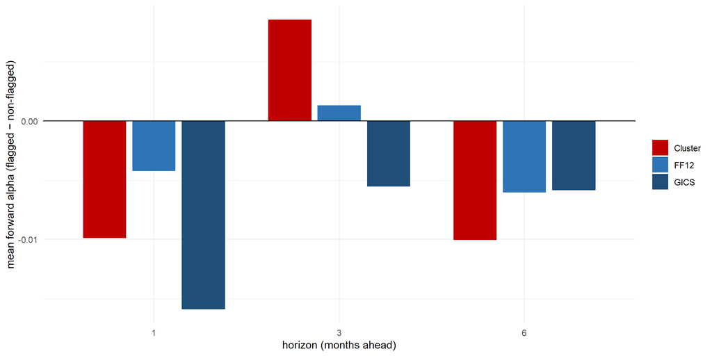

Forward alpha gap (flagged minus non-flagged) by horizon. A negative bar at +1m would suggest flagged stocks subsequently underperform on a risk-adjusted basis — the mispricing reading.

The anomaly results provide the clearest economic story in the report. The flagged portfolios generally earn more negative subsequent alpha than the non-flagged portfolios, especially at the one-month horizon and with evidence that the gap can persist out to six months. This supports the interpretation that the Isolation Forest is not merely identifying random outliers; it is flagging stocks whose recent behavior is followed by economically meaningful underperformance on a risk-adjusted basis.

Pairwise Jaccard overlap of flagged (permno, date_eom) keys

| a | b | n_a | n_b | jaccard |
| --- | --- | --- | --- | --- |
| GICS | FF12 | 173 | 172 | 0.426 |
| GICS | Cluster | 173 | 167 | 0.344 |
| FF12 | GICS | 172 | 173 | 0.426 |
| FF12 | Cluster | 172 | 167 | 0.351 |
| Cluster | GICS | 167 | 173 | 0.344 |
| Cluster | FF12 | 167 | 172 | 0.351 |

# 7. Discussion

The main result is deliberately nuanced: K-Means clusters are meaningfully different from GICS and FF12, and they add modest forecasting structure relative to the pooled baseline, but they are not automatically superior to traditional industry classifications. The strongest economic result comes from anomaly detection: stocks flagged as unusual tend to underperform non-flagged stocks on subsequent risk-adjusted returns. The right conclusion is that classification choice changes the prediction and anomaly-detection problem, not that ML clustering universally replaces GICS or SIC-based labels.

The four-dimensional comparison gives a more complete answer than any single metric:

- **Composition.** Low Rand-index values between K-Means and either of the industry schemes confirm that the unsupervised clustering finds structure that is not reducible to industry codes. The GICS-FF12 ARI is expected to be the highest of the three pairs — both partitions are ultimately built around the same notion of what a firm “does.”
- **Homogeneity.** Co-movement clusters are constructed from return-correlation information, but the K-Means solution can still be broader than traditional industry groups. If GICS or FF12 has higher `mean_within_corr`, the result should not be read as a failure of the ML approach; it means industry labels remain strong for narrow co-movement and interpretability, while K-Means is identifying a different, more cross-sector segmentation. The alpha-dispersion comparison is also important because it asks whether a grouping organizes *unexplained* return behavior, not just raw return similarity.
- **Prediction.** The Cluster model is the only grouped scheme that beats the pooled baseline on both out-of-sample R² and directional accuracy in this render. GICS and FF12 remain useful and interpretable, but their finer partitions can pay a bias-variance cost because each sector or industry regression has less training data. The practical interpretation is that a coarse co-movement split captures broad risk-regime structure that the pooled model misses without over-fragmenting the sample.
- **Anomalies.** The anomaly analysis is the most concrete economic result. Stocks flagged as unusual subsequently earn more negative forward alpha than non-flagged stocks, especially at the one-month horizon, and the gap does not disappear immediately at longer horizons. The overlap table also shows that the three schemes do not flag exactly the same stocks, so the grouping choice changes which names are treated as abnormal rather than merely changing the label attached to the same outlier set.

Two caveats remain. First, even though this version is rendered with the larger S&P 500 panel rather than the earlier 50-stock dev sample, the results should still be interpreted as a proof-of-concept classification experiment rather than a deployable trading model. Second, the alpha computation is itself dependent on the FF5 specification — alpha that the FF5 model fails to absorb might still be priced by extensions such as momentum, quality, or short-term reversal. Our anomaly definition is therefore “FF5-residual,” not “genuinely unexplained.”

# 8. Limitations and next steps

- **Universe and robustness.** This version is rendered with `CFG$dev_mode = FALSE`, so the 50-stock development sample is no longer the basis for the reported results. The next step is not simply a larger run, but robustness testing across alternative sample periods, cluster counts, and feature windows.
- **Cluster stability.** The annual-refit + Hungarian-matching pipeline keeps cluster IDs stable but doesn’t guarantee that the underlying groupings are stable. A robustness check that varies the refit window (say, 36 vs. 60 vs. 84 months) would be useful.
- **Alternative anomaly horizons.** Six months is the longest forward horizon we report. Some mispricing-reversion stories play out over a year or longer; extending the horizon would test those.
- **Sector-conditional clustering.** A natural follow-up is K-Means *within* GICS sectors — does sub-sectoral clustering find structure that flat clustering misses?

# Outputs

| file | size_kb |
| --- | --- |
| data/processed/clusters_annual.parquet | 25.0 |
| data/processed/clusters_diag.parquet | 1.4 |
| data/processed/features.parquet | 7273.9 |
| data/processed/panel.parquet | 1214.6 |
| data/raw/ccm_gics.parquet | 13.6 |
| data/raw/crsp_msf.parquet | 1106.8 |
| data/raw/crsp_sic_history.parquet | 6.3 |
| data/raw/crsp_stocknames.parquet | 17.9 |
| data/raw/ff12_def.parquet | 3.0 |
| data/raw/ff5.parquet | 26.6 |
| data/raw/fred_dff.parquet | 184.1 |
| data/raw/fred_dgs10.parquet | 125.3 |
| data/raw/fred_vixcls.parquet | 79.0 |
| data/raw/sp500_members.parquet | 9.6 |